# AT&T face data

The AT&T face dataset retrieved from (https://git-disl.github.io/GTDLBench/datasets/att_face_dataset/), “(formerly ‘The ORL Database of Faces’), contains a set of face images taken between April 1992 and April 1994 at the lab. The database was used in the context of a face recognition project carried out in collaboration with the Speech, Vision and Robotics Group of the Cambridge University Engineering Department.

```python
from sklearn.preprocessing import StandardScaler
from sklearn.model_selection import train_test_split
from sklearn.decomposition import PCA
import matplotlib.pyplot as plt
import pandas as pd
import numpy as np
import warnings
warnings.filterwarnings("ignore")
import packages_and_functions as func
```

# Data Structure

- Every feature represents the specific location of the image.
- Target number is the subject ID.

```python
data = pd.read_csv("face_data.csv")
data.head()
```

|  | 0 | 1 | 2 | 3 | 4 | 5 | 6 | 7 | 8 | 9 | ... | 4087 | 4088 | 4089 | 4090 | 4091 | 4092 | 4093 | 4094 | 4095 | target |
| --- | --- | --- | --- | --- | --- | --- | --- | --- | --- | --- | --- | --- | --- | --- | --- | --- | --- | --- | --- | --- | --- |
| 0 | 0.309917 | 0.367769 | 0.417355 | 0.442149 | 0.528926 | 0.607438 | 0.657025 | 0.677686 | 0.690083 | 0.685950 | ... | 0.669422 | 0.652893 | 0.661157 | 0.475207 | 0.132231 | 0.148760 | 0.152893 | 0.161157 | 0.157025 | 0 |
| 1 | 0.454545 | 0.471074 | 0.512397 | 0.557851 | 0.595041 | 0.640496 | 0.681818 | 0.702479 | 0.710744 | 0.702479 | ... | 0.157025 | 0.136364 | 0.148760 | 0.152893 | 0.152893 | 0.152893 | 0.152893 | 0.152893 | 0.152893 | 0 |
| 2 | 0.318182 | 0.400826 | 0.491736 | 0.528926 | 0.586777 | 0.657025 | 0.681818 | 0.685950 | 0.702479 | 0.698347 | ... | 0.132231 | 0.181818 | 0.136364 | 0.128099 | 0.148760 | 0.144628 | 0.140496 | 0.148760 | 0.152893 | 0 |
| 3 | 0.198347 | 0.194215 | 0.194215 | 0.194215 | 0.190083 | 0.190083 | 0.243802 | 0.404959 | 0.483471 | 0.516529 | ... | 0.636364 | 0.657025 | 0.685950 | 0.727273 | 0.743802 | 0.764463 | 0.752066 | 0.752066 | 0.739669 | 0 |
| 4 | 0.500000 | 0.545455 | 0.582645 | 0.623967 | 0.648760 | 0.690083 | 0.694215 | 0.714876 | 0.723140 | 0.731405 | ... | 0.161157 | 0.177686 | 0.173554 | 0.177686 | 0.177686 | 0.177686 | 0.177686 | 0.173554 | 0.173554 | 0 |

5 rows × 4097 columns

## Part1. Original Data

### Data Preprocessing

- Split the data into train and test part (the parameter - stratify - ensures every people gets involved in train and test data)
- Standardization

Note: we assume that the test data is invisible, so we standardize test data with mean and std from train data.

```python
X = data.drop('target', axis=1)
y = data['target']
group = np.unique(y)

X_train, X_test, y_train, y_test = train_test_split(X, y, test_size=0.30, random_state = 410878048, stratify=y)


# Standardize the test data by means and std from train data
X_var_mean = np.array(np.mean(X_train, axis = 0)).reshape(1, -1)
X_var_std = np.array(np.std(X_train, axis = 0)).reshape(1, -1)
X_test = (X_test - X_var_mean)/ X_var_std

# Standardize the train data
scaler = StandardScaler()
X_train = scaler.fit_transform(X_train)
```

### Grid Search

In order to get the maximized result, we in advance perform grid search.

That is, we repeat the process of training and testing under different sets of parameters.

Then, grid search would give us eventually the best parameter that achieves the highest matrices.

The final result shows, in training data, logistic regression model would get most excellent score under the set of parameter {'max_iter': 100, 'n_jobs': -1, 'penalty': 'l2', 'solver': 'lbfgs'}.

```python
# Logistics Regression parameters
params = {
    'penalty': ['l1', 'l2'],
    'solver': ['lbfgs'],
    'max_iter': [100], "n_jobs" : [-1]
}
print("Logistic Regression")
log_params = func.gridSearch("LogisticReg", params, X_train, y_train)

# SVM parameters
params = {
    'C': [0.1],
    'kernel': ['linear', 'rbf'],
    'gamma': ['scale'],
    'degree': [2],
    'tol': [1e-5],
    'max_iter': [100]
}
print("SVM")
svm_params = func.gridSearch("SVM", params, X_train, y_train)

# Neural Network parameters
# Define a dictionary of hyperparameters to search over
params = {
    'hidden_layer_sizes': [(50,), (100,100)],
    'activation': ['relu', 'logistic'],
    'solver': [ 'adam'],
    'alpha': [ 0.01],
    'max_iter': [100],
    'tol': [1e-5]
}
print("Neural Network")
nn_params = func.gridSearch("NeuralNetwork", params, X_train, y_train)
```

```
Logistic Regression
Best hyperparameters: {'max_iter': 100, 'n_jobs': -1, 'penalty': 'l2', 'solver': 'lbfgs'}
Best score: 0.95
SVM
Best hyperparameters: {'C': 0.1, 'degree': 2, 'gamma': 'scale', 'kernel': 'linear', 'max_iter': 100, 'tol': 1e-05}
Best score: 0.9321428571428573
Neural Network
Best hyperparameters: {'activation': 'logistic', 'alpha': 0.01, 'hidden_layer_sizes': (50,), 'max_iter': 100, 'solver': 'adam', 'tol': 1e-05}
Best score: 0.9321428571428572
```

### Classification Result

- heatmaps of confusion matrix

  Every matrix shows a classfication result by an algorithm.

  The diagonal elements are correctly classified, while other elements on other cells are misclassified.

  Overall, three model achieve decent performance after we tune the parameters

```python
datas = [X_train, y_train, X_test, y_test]
CM_LogReg, _ = func.classificationChoice("LogisticReg", group, *datas, paras_dict = log_params)
CM_SVM, _ = func.classificationChoice("SVM", group, *datas, paras_dict = svm_params)
CM_NeuralNetwork, _ = func.classificationChoice("NeuralNetwork", group, *datas, paras_dict = nn_params)
```

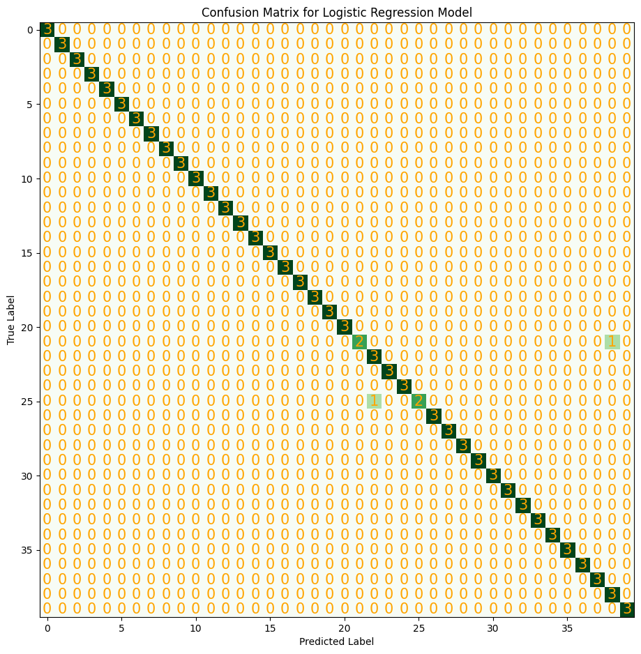

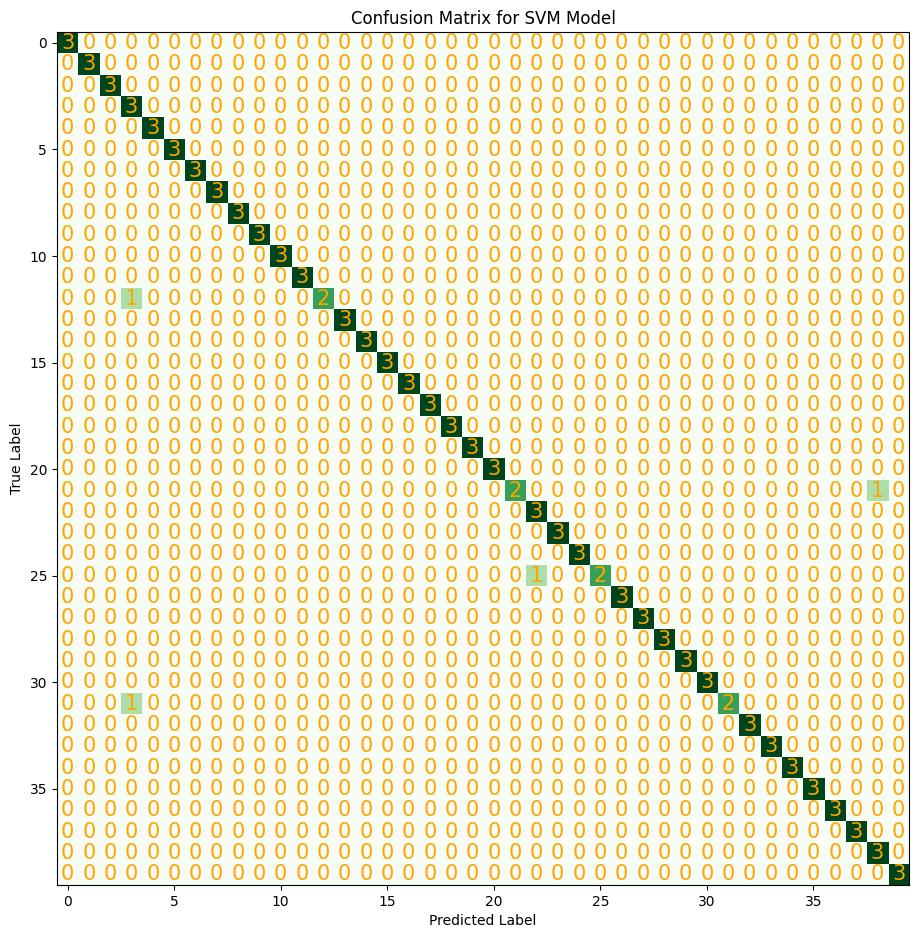

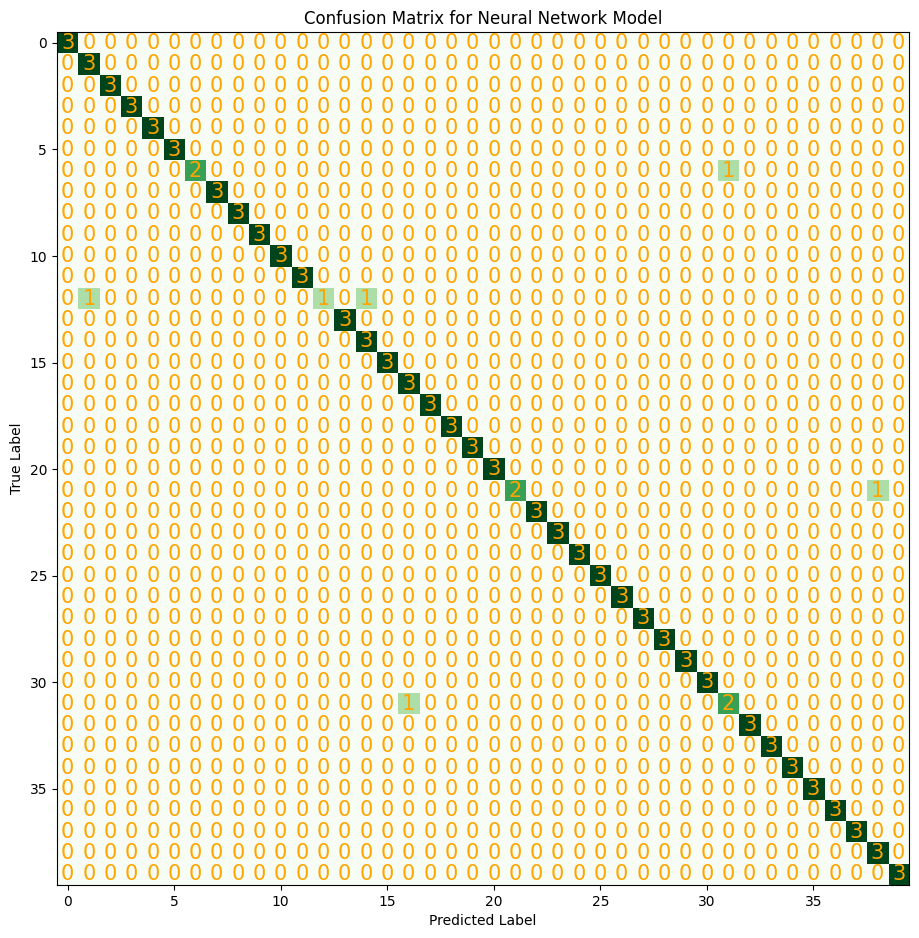

```python
model = ["Logistic Regression", "SVM", "Neural Network"]
for i, CM in enumerate([CM_LogReg, CM_SVM, CM_NeuralNetwork]):
    plt.figure(figsize=(11, 15))
    # Create a heatmap of the confusion matrix using seaborn
    plt.imshow(CM, cmap='Greens')

    # Add text to each cell of the heatmap
    for j in range(CM.shape[0]):
        for k in range(CM.shape[1]):
            text = plt.text(k, j, f'{CM[j, k]}', ha='center', va='center', color='Orange', fontsize=15)

    # Add labels for the x and y axes
    plt.xlabel('Predicted Label')
    plt.ylabel('True Label')
    plt.title(f'Confusion Matrix for {model[i]} Model')
    plt.show()
```

- Table of index

  When the index is below 60%, we color the cell in purple.

  From the viewpoint of precision and recall, Logistic regression model achieves the best performance with high averaged recall (98.3%) and high averaged precision (98.8%).

  These precentages vary greatly because denominator of percentage is small (only 3).

```python
subject_id = ["Subject " + str(i) for i in range(1, len(np.unique(y)) + 1)]
func.modelResult([CM_LogReg, CM_SVM, CM_NeuralNetwork], subject_id)
```

|  | Precision(%) Logistic Regression | Precision(%) SVM | Precision(%) NeuralNetwork | Recall(%) Logistic Regression | Recall(%) SVM | Recall(%) NeuralNetwork |
| --- | --- | --- | --- | --- | --- | --- |
| Subject 1 | 100.0 | 100.0 | 100.0 | 100.0 | 100.0 | 100.0 |
| Subject 2 | 100.0 | 100.0 | 75.0 | 100.0 | 100.0 | 100.0 |
| Subject 3 | 100.0 | 100.0 | 100.0 | 100.0 | 100.0 | 100.0 |
| Subject 4 | 100.0 | 60.0 | 100.0 | 100.0 | 100.0 | 100.0 |
| Subject 5 | 100.0 | 100.0 | 100.0 | 100.0 | 100.0 | 100.0 |
| Subject 6 | 100.0 | 100.0 | 100.0 | 100.0 | 100.0 | 100.0 |
| Subject 7 | 100.0 | 100.0 | 100.0 | 100.0 | 100.0 | 66.7 |
| Subject 8 | 100.0 | 100.0 | 100.0 | 100.0 | 100.0 | 100.0 |
| Subject 9 | 100.0 | 100.0 | 100.0 | 100.0 | 100.0 | 100.0 |
| Subject 10 | 100.0 | 100.0 | 100.0 | 100.0 | 100.0 | 100.0 |
| Subject 11 | 100.0 | 100.0 | 100.0 | 100.0 | 100.0 | 100.0 |
| Subject 12 | 100.0 | 100.0 | 100.0 | 100.0 | 100.0 | 100.0 |
| Subject 13 | 100.0 | 100.0 | 100.0 | 100.0 | 66.7 | 33.3 |
| Subject 14 | 100.0 | 100.0 | 100.0 | 100.0 | 100.0 | 100.0 |
| Subject 15 | 100.0 | 100.0 | 75.0 | 100.0 | 100.0 | 100.0 |
| Subject 16 | 100.0 | 100.0 | 100.0 | 100.0 | 100.0 | 100.0 |
| Subject 17 | 100.0 | 100.0 | 75.0 | 100.0 | 100.0 | 100.0 |
| Subject 18 | 100.0 | 100.0 | 100.0 | 100.0 | 100.0 | 100.0 |
| Subject 19 | 100.0 | 100.0 | 100.0 | 100.0 | 100.0 | 100.0 |
| Subject 20 | 100.0 | 100.0 | 100.0 | 100.0 | 100.0 | 100.0 |
| Subject 21 | 100.0 | 100.0 | 100.0 | 100.0 | 100.0 | 100.0 |
| Subject 22 | 100.0 | 100.0 | 100.0 | 66.7 | 66.7 | 66.7 |
| Subject 23 | 75.0 | 75.0 | 100.0 | 100.0 | 100.0 | 100.0 |
| Subject 24 | 100.0 | 100.0 | 100.0 | 100.0 | 100.0 | 100.0 |
| Subject 25 | 100.0 | 100.0 | 100.0 | 100.0 | 100.0 | 100.0 |
| Subject 26 | 100.0 | 100.0 | 100.0 | 66.7 | 66.7 | 100.0 |
| Subject 27 | 100.0 | 100.0 | 100.0 | 100.0 | 100.0 | 100.0 |
| Subject 28 | 100.0 | 100.0 | 100.0 | 100.0 | 100.0 | 100.0 |
| Subject 29 | 100.0 | 100.0 | 100.0 | 100.0 | 100.0 | 100.0 |
| Subject 30 | 100.0 | 100.0 | 100.0 | 100.0 | 100.0 | 100.0 |
| Subject 31 | 100.0 | 100.0 | 100.0 | 100.0 | 100.0 | 100.0 |
| Subject 32 | 100.0 | 100.0 | 66.7 | 100.0 | 66.7 | 66.7 |
| Subject 33 | 100.0 | 100.0 | 100.0 | 100.0 | 100.0 | 100.0 |
| Subject 34 | 100.0 | 100.0 | 100.0 | 100.0 | 100.0 | 100.0 |
| Subject 35 | 100.0 | 100.0 | 100.0 | 100.0 | 100.0 | 100.0 |
| Subject 36 | 100.0 | 100.0 | 100.0 | 100.0 | 100.0 | 100.0 |
| Subject 37 | 100.0 | 100.0 | 100.0 | 100.0 | 100.0 | 100.0 |
| Subject 38 | 100.0 | 100.0 | 100.0 | 100.0 | 100.0 | 100.0 |
| Subject 39 | 75.0 | 75.0 | 75.0 | 100.0 | 100.0 | 100.0 |
| Subject 40 | 100.0 | 100.0 | 100.0 | 100.0 | 100.0 | 100.0 |
| Mean | 98.8 | 97.8 | 96.7 | 98.3 | 96.7 | 95.8 |

## Part2. PCA Data

### Data Preprocessing

- With dimensionality reduction, we retrieve few but more important variables from original data. Then, we check if the classification would be improved
- Retain 25 variables which account for more than 80% variance of original data
- Train test split -> Standization -> PCA

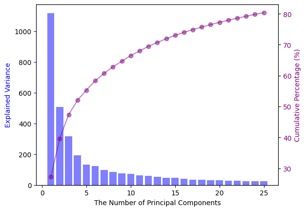

```python
X_train, X_test, y_train, y_test = train_test_split(X, y, test_size=0.30, random_state = 410878048, stratify=y)
# Standardize the test data by means and std from train data
X_var_mean = np.array(np.mean(X_train, axis = 0)).reshape(1, -1)
X_var_std = np.array(np.std(X_train, axis = 0)).reshape(1, -1)
X_test_std = (X_test - X_var_mean)/ X_var_std

# Standardize the train data
scaler = StandardScaler()
X_train_std = scaler.fit_transform(X_train)

pca = PCA()
pca.fit(X_train_std)
# decide the retained number of PCs
cumulative_variances = np.cumsum(pca.explained_variance_)
percentage = [x/X.shape[1] * 100 for x in cumulative_variances]
number_retained = list(np.array(percentage) > 80).count(False) + 1
explained_variance = pca.explained_variance_[:number_retained]
tick_of_pc = [x for x in range(1, len(explained_variance)+1)]

X_train = pca.transform(X_train_std)[:, :number_retained]
X_test = pca.transform(X_test_std)[:, :number_retained]

# show pca result
## plot bar chart
color1 = "blue"
plt.bar(tick_of_pc, explained_variance, color=color1, alpha=0.5)
plt.xlabel('The Number of Principal Components')
plt.ylabel('Explained Variance', color=color1)
plt.tick_params(axis='y', color=color1)
## create secondary y-axis
ax3 = plt.twinx()
## plot cumulative percentage line chart
ax3.plot(tick_of_pc, percentage[:number_retained], color='purple', marker='o', alpha = 0.5)
ax3.set_ylabel('Cumulative Percentage (%)', color='purple')
ax3.tick_params(axis='y', labelcolor='purple')
```

### Grid Search

In PCA data, the final result shows Neural network model would get most excellent score under the set of parameter

{'activation': 'tanh', 'alpha': 0.01, 'hidden_layer_sizes': (100,), 'max_iter': 1000, 'solver': 'lbfgs', 'tol': 1e-05}

```python
# Logistics Regression parameters
params = {
    'penalty': ['l1', 'l2', 'elasticnet'],
    'C': [0.1, 1, 10],
    'solver': ['newton-cg', 'lbfgs', 'sag'],
    'max_iter': [1000], "n_jobs" : [-1]
}
print("Logistic Regression")
log_params = func.gridSearch("LogisticReg", params, X_train, y_train)

# SVM parameters
params = {
    'C': [0.1, 1, 10],
    'kernel': ['linear', 'rbf'],
    'gamma': ['scale', 'auto'],
    'degree': [2, 5],
    'tol': [1e-5],
    'max_iter': [1000]
}
print("SVM")
svm_params = func.gridSearch("SVM", params, X_train, y_train)

# Neural Network parameters
# Define a dictionary of hyperparameters to search over
params = {
    'hidden_layer_sizes': [(50,), (100,), (100,100)],
    'activation': ['relu', 'tanh', 'logistic'],
    'solver': ['lbfgs', 'sgd', 'adam'],
    'alpha': [0.0001, 0.01],
    'max_iter': [1000],
    'tol': [1e-5]
}
print("Neural Network")
nn_params = func.gridSearch("NeuralNetwork", params, X_train, y_train)
```

```
Logistic Regression
Best hyperparameters: {'C': 0.1, 'max_iter': 1000, 'n_jobs': -1, 'penalty': 'l2', 'solver': 'newton-cg'}
Best score: 0.9357142857142857
SVM
Best hyperparameters: {'C': 0.1, 'degree': 2, 'gamma': 'scale', 'kernel': 'linear', 'max_iter': 1000, 'tol': 1e-05}
Best score: 0.9214285714285715
Neural Network
Best hyperparameters: {'activation': 'tanh', 'alpha': 0.01, 'hidden_layer_sizes': (100,), 'max_iter': 1000, 'solver': 'lbfgs', 'tol': 1e-05}
Best score: 0.9607142857142857
```

```python
datas = [X_train, y_train, X_test, y_test]
CM_LogReg, _ = func.classificationChoice("LogisticReg", group, *datas, paras_dict = log_params)
CM_SVM, _ = func.classificationChoice("SVM", group, *datas, paras_dict = svm_params)
CM_NeuralNetwork, _ = func.classificationChoice("NeuralNetwork", group, *datas, paras_dict = nn_params)
```

### Classification Result

- heatmaps of confusion matrix

  Compared with 3 models, Neural network model preforms better than other models.

  The result is consistent with grid search.

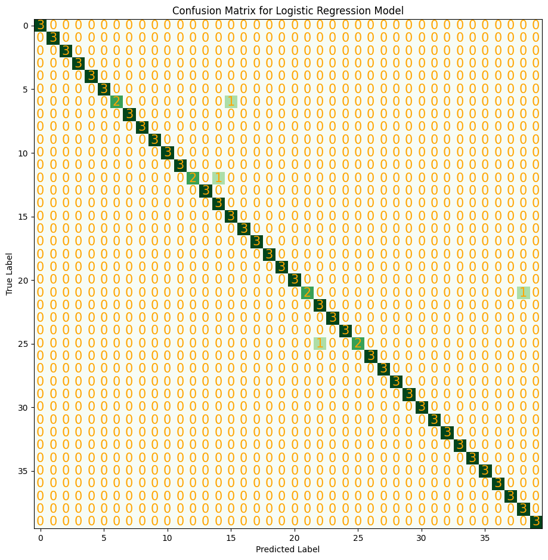

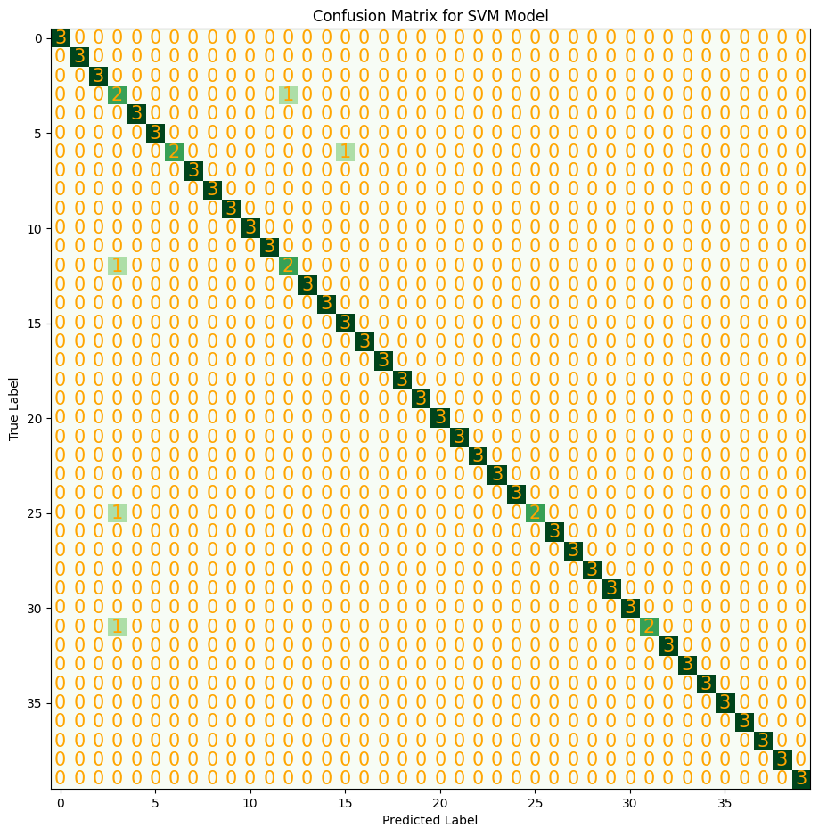

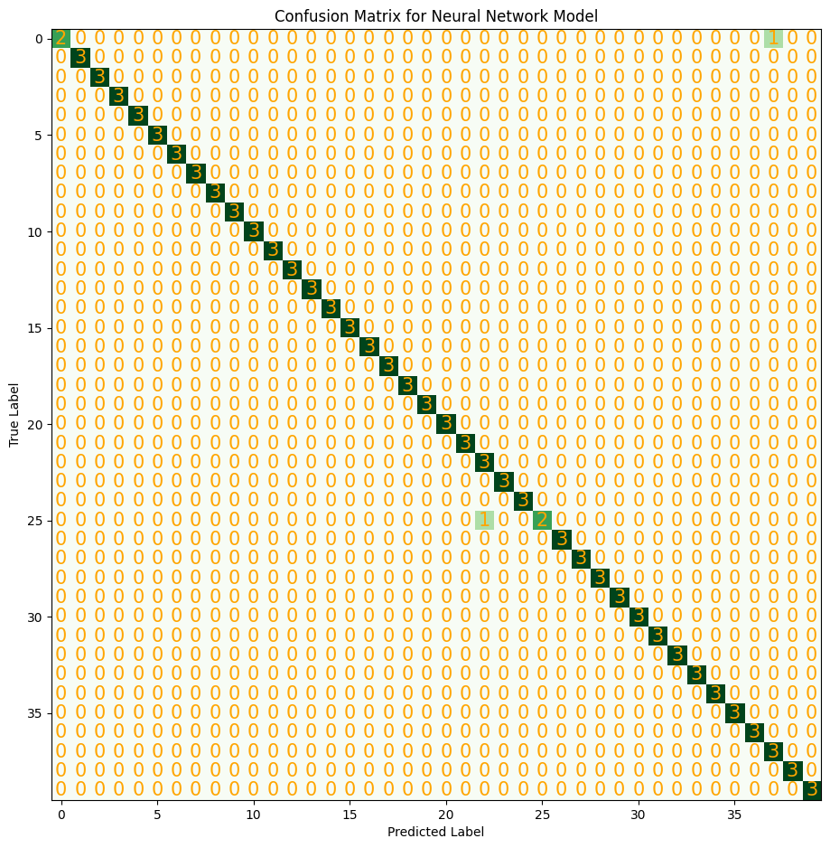

```python
model = ["Logistic Regression", "SVM", "Neural Network"]
for i, CM in enumerate([CM_LogReg, CM_SVM, CM_NeuralNetwork]):
    plt.figure(figsize=(11, 15))
    # Create a heatmap of the confusion matrix using seaborn
    plt.imshow(CM, cmap='Greens')

    # Add text to each cell of the heatmap
    for j in range(CM.shape[0]):
        for k in range(CM.shape[1]):
            text = plt.text(k, j, f'{CM[j, k]}', ha='center', va='center', color='Orange', fontsize=15)

    # Add labels for the x and y axes
    plt.xlabel('Predicted Label')
    plt.ylabel('True Label')
    plt.title(f'Confusion Matrix for {model[i]} Model')
    plt.show()
```

- Table of index

  In pca data, most of subjects can be classified correctly.

  Among 3 models, like heatmaps, Neural Network model achieve the best performance with high averaged recall (98.3%) and high averaged precision (98.8%).

```python
func.modelResult([CM_LogReg, CM_SVM, CM_NeuralNetwork], subject_id)
```

|  | Precision(%) Logistic Regression | Precision(%) SVM | Precision(%) NeuralNetwork | Recall(%) Logistic Regression | Recall(%) SVM | Recall(%) NeuralNetwork |
| --- | --- | --- | --- | --- | --- | --- |
| Subject 1 | 100.0 | 100.0 | 100.0 | 100.0 | 100.0 | 66.7 |
| Subject 2 | 100.0 | 100.0 | 100.0 | 100.0 | 100.0 | 100.0 |
| Subject 3 | 100.0 | 100.0 | 100.0 | 100.0 | 100.0 | 100.0 |
| Subject 4 | 100.0 | 40.0 | 100.0 | 100.0 | 66.7 | 100.0 |
| Subject 5 | 100.0 | 100.0 | 100.0 | 100.0 | 100.0 | 100.0 |
| Subject 6 | 100.0 | 100.0 | 100.0 | 100.0 | 100.0 | 100.0 |
| Subject 7 | 100.0 | 100.0 | 100.0 | 66.7 | 66.7 | 100.0 |
| Subject 8 | 100.0 | 100.0 | 100.0 | 100.0 | 100.0 | 100.0 |
| Subject 9 | 100.0 | 100.0 | 100.0 | 100.0 | 100.0 | 100.0 |
| Subject 10 | 100.0 | 100.0 | 100.0 | 100.0 | 100.0 | 100.0 |
| Subject 11 | 100.0 | 100.0 | 100.0 | 100.0 | 100.0 | 100.0 |
| Subject 12 | 100.0 | 100.0 | 100.0 | 100.0 | 100.0 | 100.0 |
| Subject 13 | 100.0 | 66.7 | 100.0 | 66.7 | 66.7 | 100.0 |
| Subject 14 | 100.0 | 100.0 | 100.0 | 100.0 | 100.0 | 100.0 |
| Subject 15 | 75.0 | 100.0 | 100.0 | 100.0 | 100.0 | 100.0 |
| Subject 16 | 75.0 | 75.0 | 100.0 | 100.0 | 100.0 | 100.0 |
| Subject 17 | 100.0 | 100.0 | 100.0 | 100.0 | 100.0 | 100.0 |
| Subject 18 | 100.0 | 100.0 | 100.0 | 100.0 | 100.0 | 100.0 |
| Subject 19 | 100.0 | 100.0 | 100.0 | 100.0 | 100.0 | 100.0 |
| Subject 20 | 100.0 | 100.0 | 100.0 | 100.0 | 100.0 | 100.0 |
| Subject 21 | 100.0 | 100.0 | 100.0 | 100.0 | 100.0 | 100.0 |
| Subject 22 | 100.0 | 100.0 | 100.0 | 66.7 | 100.0 | 100.0 |
| Subject 23 | 75.0 | 100.0 | 75.0 | 100.0 | 100.0 | 100.0 |
| Subject 24 | 100.0 | 100.0 | 100.0 | 100.0 | 100.0 | 100.0 |
| Subject 25 | 100.0 | 100.0 | 100.0 | 100.0 | 100.0 | 100.0 |
| Subject 26 | 100.0 | 100.0 | 100.0 | 66.7 | 66.7 | 66.7 |
| Subject 27 | 100.0 | 100.0 | 100.0 | 100.0 | 100.0 | 100.0 |
| Subject 28 | 100.0 | 100.0 | 100.0 | 100.0 | 100.0 | 100.0 |
| Subject 29 | 100.0 | 100.0 | 100.0 | 100.0 | 100.0 | 100.0 |
| Subject 30 | 100.0 | 100.0 | 100.0 | 100.0 | 100.0 | 100.0 |
| Subject 31 | 100.0 | 100.0 | 100.0 | 100.0 | 100.0 | 100.0 |
| Subject 32 | 100.0 | 100.0 | 100.0 | 100.0 | 66.7 | 100.0 |
| Subject 33 | 100.0 | 100.0 | 100.0 | 100.0 | 100.0 | 100.0 |
| Subject 34 | 100.0 | 100.0 | 100.0 | 100.0 | 100.0 | 100.0 |
| Subject 35 | 100.0 | 100.0 | 100.0 | 100.0 | 100.0 | 100.0 |
| Subject 36 | 100.0 | 100.0 | 100.0 | 100.0 | 100.0 | 100.0 |
| Subject 37 | 100.0 | 100.0 | 100.0 | 100.0 | 100.0 | 100.0 |
| Subject 38 | 100.0 | 100.0 | 75.0 | 100.0 | 100.0 | 100.0 |
| Subject 39 | 75.0 | 100.0 | 100.0 | 100.0 | 100.0 | 100.0 |
| Subject 40 | 100.0 | 100.0 | 100.0 | 100.0 | 100.0 | 100.0 |
| Mean | 97.5 | 97.0 | 98.8 | 96.7 | 95.8 | 98.3 |

# Conclusion

- These three models can be applied to image recognition.
- Grid search provide us with a clear view of which the set of parameter can produce the best result.
- In original data, logistic regression can achieve the best 98.8% averaged precision and 98.3% averaged recall value.
- In PCA data, Neural network can achieve the best 98.8% averaged precision and 98.3% averaged recall value. Both of them has nearly perfect classification and successfully reduces features from 4096 to 25.
- In this case, we prefer watching averaged index not individual index because individual only contributes 3 observations which results in a higher degree of variation in percentage.
- In next case, Yale face data, it provides a more stable index with larger test data and we will discuss the advantage of PCA data.